# Tekentoets

Disclaimer: Het peer review proces voor deze toets is nog niet afgerond; daarom is deze pagina nog in concept.

# 1 Toepassing

Gebruik de *tekentoets* om de mediaan van een steekproef te vergelijken met een bekende mediaan of norm in een populatie.[^1] Deze toets is een alternatief voor de one sample t-toets wanneer de data niet normaal verdeeld is. De Wilcoxon signed rank toets kan ook gebruikt worden om de mediaan van een steekproef te vergelijken met een bekende mediaan. Deze toets heeft een hoger onderscheidend vermogen[^2], maar vereist dat de verdeling van de data symmetrisch is.[^3] De *tekentoets* kan ook gebruikt worden als de verdeling van de data niet symmetrisch is.

# 2 Onderwijscasus

# 3 Assumpties

Het meetniveau van de variabele is continu.[^5]

# 4 Uitvoering

Er is data ingeladen met jaarlijkse bruto inkomens van alumni van de school voor Journalistiek genaamd `dfJaarlijks_inkomen`. De directeur wil kijken hoe haar oud-studenten scoren ten opzichte van het modale inkomen in Nederland.

## 4.1 De data bekijken

Gebruik `<dataframe>.head()` en `<dataframe>.tail()` om de structuur van de data te bekijken.

```python
# Pandas library importeren
import pandas as pd
```

```python
# Eerste 6 observaties
print(dfJaarlijks_inkomen.head(6))
```

```
##   Studentnummer  Inkomen
## 0       4466713  44047.0
## 1       4000958  66004.0
## 2       4136967  49442.0
## 3       4090719  42890.0
## 4       4414229  59478.0
## 5       4191784  61857.0
```

```python
# Laatste 6 observaties
print(dfJaarlijks_inkomen.tail(6))
```

```
##    Studentnummer  Inkomen
## 23       4061987  34349.0
## 24       4401307  32022.0
## 25       4179848  66667.0
## 26       4392861  42721.0
## 27       4425075  43956.0
## 28       4016485  38288.0
```

Inspecteer de data met `np.mean()`, `np.std()`, `np.median()` en `len()` van het package `numpy` om meer inzicht te krijgen in de data.

```python
import numpy as np

np.mean(dfJaarlijks_inkomen['Inkomen'])
```

```
## 50902.48275862069
```

```python
np.std(dfJaarlijks_inkomen['Inkomen'])
```

```
## 14258.773066191601
```

```python
np.median(dfJaarlijks_inkomen['Inkomen'])
```

```
## 49234.0
```

```python
len(dfJaarlijks_inkomen['Inkomen'])
```

```
## 29
```

Het gemiddelde jaarinkomen van de alumni is €50902 met een standaardafwijking van €14258,77 (*n* = 29). De mediaan van het inkomen is €49234.

## 4.2 De data visualiseren

Visualiseer de data om een goed beeld van de jaarinkomens van de alumni te krijgen. Geef de verdeling van de data weer in een histogram[^6]. Focus bij het analyseren van een histogram op de symmetrie van de verdeling, de hoeveelheid toppen (modaliteit) en mogelijke uitbijters.[^7]<sup>,</sup>[^8]

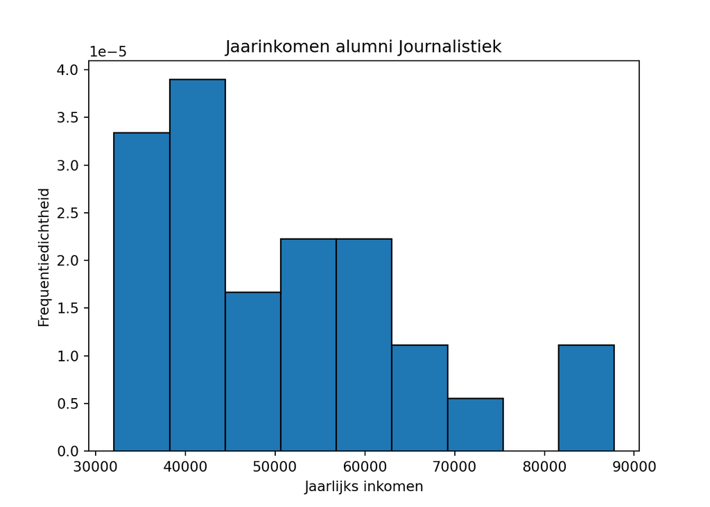

```python
 ## Histogram met matplotlib
import matplotlib.pyplot as plt
hist = plt.hist(dfJaarlijks_inkomen['Inkomen'], density = True, edgecolor = "black", bins = 9)
title = plt.title("Jaarinkomen alumni Journalistiek")
xlab = plt.xlabel("Jaarlijks inkomen")
ylab = plt.ylabel("Frequentiedichtheid")
plt.show()
```